# Red Wine EDA by Will Tays

I chose the red wine dataset for a few personal reasons. I enjoy drinking red wine, and I’m a chemist. Howerver, I’ve never considered studying the chemistry underlying wine. This project allowed me the time to dig into how a wine is made and all the chemical components that must be balanced to create a quality wine.

# Data attributes and structure

```
##   fixed.acidity volatile.acidity citric.acid residual.sugar chlorides
## 1           7.4             0.70        0.00            1.9     0.076
## 2           7.8             0.88        0.00            2.6     0.098
## 3           7.8             0.76        0.04            2.3     0.092
## 4          11.2             0.28        0.56            1.9     0.075
## 5           7.4             0.70        0.00            1.9     0.076
## 6           7.4             0.66        0.00            1.8     0.075
##   free.sulfur.dioxide total.sulfur.dioxide density   pH sulphates alcohol
## 1                  11                   34  0.9978 3.51      0.56     9.4
## 2                  25                   67  0.9968 3.20      0.68     9.8
## 3                  15                   54  0.9970 3.26      0.65     9.8
## 4                  17                   60  0.9980 3.16      0.58     9.8
## 5                  11                   34  0.9978 3.51      0.56     9.4
## 6                  13                   40  0.9978 3.51      0.56     9.4
##   quality
## 1       5
## 2       5
## 3       5
## 4       6
## 5       5
## 6       5
```

```
## [1] 1599   12
```

```
##  [1] "fixed.acidity"        "volatile.acidity"     "citric.acid"
##  [4] "residual.sugar"       "chlorides"            "free.sulfur.dioxide"
##  [7] "total.sulfur.dioxide" "density"              "pH"
## [10] "sulphates"            "alcohol"              "quality"
```

```
## 'data.frame':    1599 obs. of  12 variables:
##  $ fixed.acidity       : num  7.4 7.8 7.8 11.2 7.4 7.4 7.9 7.3 7.8 7.5 ...
##  $ volatile.acidity    : num  0.7 0.88 0.76 0.28 0.7 0.66 0.6 0.65 0.58 0.5 ...
##  $ citric.acid         : num  0 0 0.04 0.56 0 0 0.06 0 0.02 0.36 ...
##  $ residual.sugar      : num  1.9 2.6 2.3 1.9 1.9 1.8 1.6 1.2 2 6.1 ...
##  $ chlorides           : num  0.076 0.098 0.092 0.075 0.076 0.075 0.069 0.065 0.073 0.071 ...
##  $ free.sulfur.dioxide : num  11 25 15 17 11 13 15 15 9 17 ...
##  $ total.sulfur.dioxide: num  34 67 54 60 34 40 59 21 18 102 ...
##  $ density             : num  0.998 0.997 0.997 0.998 0.998 ...
##  $ pH                  : num  3.51 3.2 3.26 3.16 3.51 3.51 3.3 3.39 3.36 3.35 ...
##  $ sulphates           : num  0.56 0.68 0.65 0.58 0.56 0.56 0.46 0.47 0.57 0.8 ...
##  $ alcohol             : num  9.4 9.8 9.8 9.8 9.4 9.4 9.4 10 9.5 10.5 ...
##  $ quality             : int  5 5 5 6 5 5 5 7 7 5 ...
```

```
##  fixed.acidity   volatile.acidity  citric.acid    residual.sugar
##  Min.   : 4.60   Min.   :0.1200   Min.   :0.000   Min.   : 0.900
##  1st Qu.: 7.10   1st Qu.:0.3900   1st Qu.:0.090   1st Qu.: 1.900
##  Median : 7.90   Median :0.5200   Median :0.260   Median : 2.200
##  Mean   : 8.32   Mean   :0.5278   Mean   :0.271   Mean   : 2.539
##  3rd Qu.: 9.20   3rd Qu.:0.6400   3rd Qu.:0.420   3rd Qu.: 2.600
##  Max.   :15.90   Max.   :1.5800   Max.   :1.000   Max.   :15.500
##    chlorides       free.sulfur.dioxide total.sulfur.dioxide
##  Min.   :0.01200   Min.   : 1.00       Min.   :  6.00
##  1st Qu.:0.07000   1st Qu.: 7.00       1st Qu.: 22.00
##  Median :0.07900   Median :14.00       Median : 38.00
##  Mean   :0.08747   Mean   :15.87       Mean   : 46.47
##  3rd Qu.:0.09000   3rd Qu.:21.00       3rd Qu.: 62.00
##  Max.   :0.61100   Max.   :72.00       Max.   :289.00
##     density             pH          sulphates         alcohol
##  Min.   :0.9901   Min.   :2.740   Min.   :0.3300   Min.   : 8.40
##  1st Qu.:0.9956   1st Qu.:3.210   1st Qu.:0.5500   1st Qu.: 9.50
##  Median :0.9968   Median :3.310   Median :0.6200   Median :10.20
##  Mean   :0.9967   Mean   :3.311   Mean   :0.6581   Mean   :10.42
##  3rd Qu.:0.9978   3rd Qu.:3.400   3rd Qu.:0.7300   3rd Qu.:11.10
##  Max.   :1.0037   Max.   :4.010   Max.   :2.0000   Max.   :14.90
##     quality
##  Min.   :3.000
##  1st Qu.:5.000
##  Median :6.000
##  Mean   :5.636
##  3rd Qu.:6.000
##  Max.   :8.000
```

# Univariate Plots

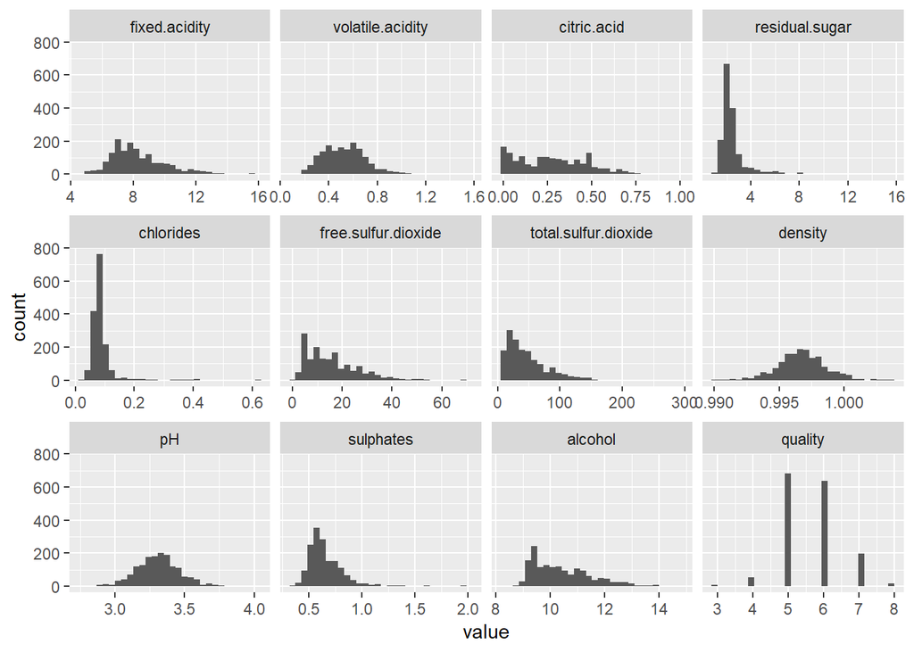

Generating a matrix of histograms for all columns provides a global view of the chemical attributes measured in the red wine contained in this data set. These attributes can be used to explore whether a single, or combination of attributes can impact the quality rating given by wine experts. Overall, each attribute seems to be normally distributed with the exception of maybe citric acid, free sulfur dioxide, and alcohol. Although normally distributed, most tend to lean or skew to the right.

We’ll zoom in on each plot to get a more detailed look at each histogram.

```
##    Min. 1st Qu.  Median    Mean 3rd Qu.    Max.
##    4.60    7.10    7.90    8.32    9.20   15.90
##    Min. 1st Qu.  Median    Mean 3rd Qu.    Max.
##  0.1200  0.3900  0.5200  0.5278  0.6400  1.5800
##    Min. 1st Qu.  Median    Mean 3rd Qu.    Max.
##   0.000   0.090   0.260   0.271   0.420   1.000
```

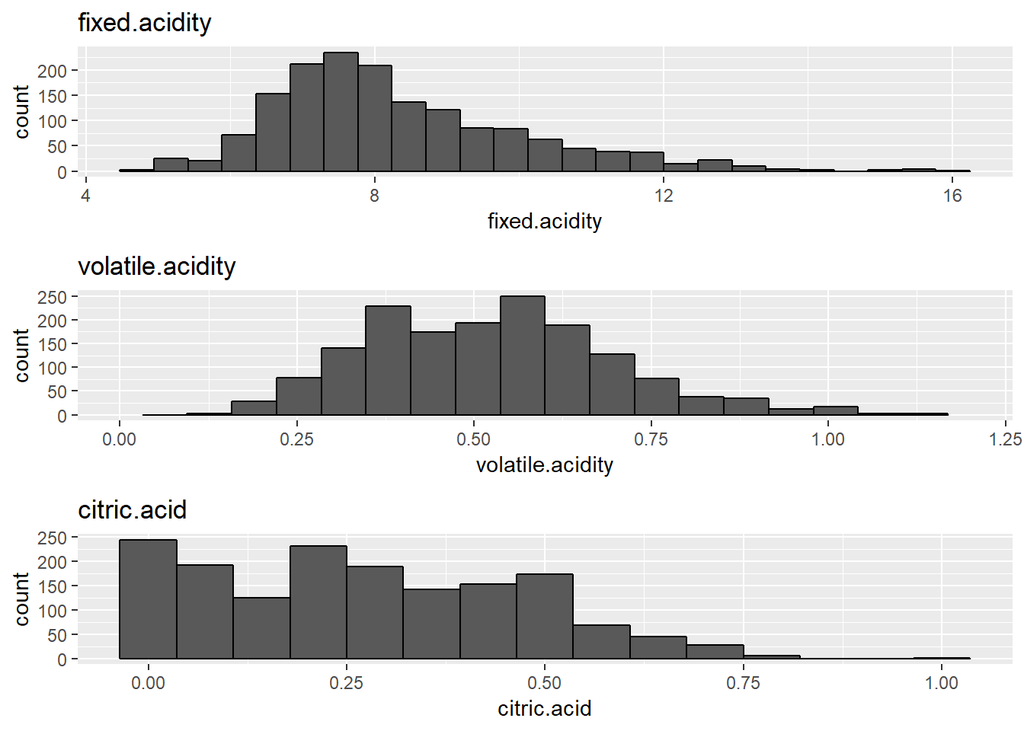

Fixed acidity (mainly tartaric acid) can determine how tart a wine may taste. We can see that a majority of the wines in the dataset contain less than 12 g/L. A high acidity wines “tartness” may be balanced with more sugar to sweeten the profile.

Volatile acids (mainly acetic acid) evaporate easier than the fixed acids in wine. High concentrations of volatile acids can casue unpleasent flavor and aroma profiles.

The histogram for citric acid is results in a distrubion which is not normally distributed. I increased and decreased the binwidth and failed to see a normal distribution. Citric acids are typically added after fermentation as doing so before may risk microbes to convert it to acetic acid, which is undesirable in the wine making process. It makes sense looking at the histgram for citric acid to see very lowconcentrations, most less than mean at 0.271 g/L.

```
##    Min. 1st Qu.  Median    Mean 3rd Qu.    Max.
##   0.900   1.900   2.200   2.539   2.600  15.500
```

```
##    Min. 1st Qu.  Median    Mean 3rd Qu.    Max.
## 0.01200 0.07000 0.07900 0.08747 0.09000 0.61100
```

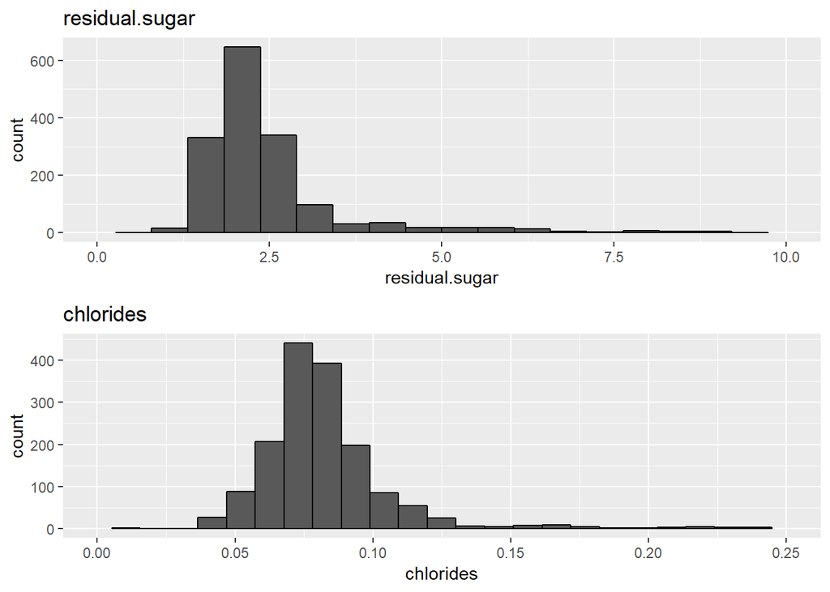

The relatively low residual sugar in these wines suggest that the flavor profiles for the bulk of this dataset is dry (or not sweet). According to the info given with the data, wines greater than 45 g/L are considered sweet. In our dataset, the max sugar content for a wine is 15.5 g/L. If we limit the x-axis (0, 10) to remove some of the outliers, the histrogram still skews heavily to the right.

The histrogram for chrlorides can be adjusted to remove values greater than 0.25 to get a better look at the distribution. Salt content in wine aims to be very minimal as wine is not meant to be salty. The salt profile comes from dry soils and even the skin of the grapes.

```
##    Min. 1st Qu.  Median    Mean 3rd Qu.    Max.
##    1.00    7.00   14.00   15.87   21.00   72.00
##    Min. 1st Qu.  Median    Mean 3rd Qu.    Max.
##    6.00   22.00   38.00   46.47   62.00  289.00
##    Min. 1st Qu.  Median    Mean 3rd Qu.    Max.
##  0.3300  0.5500  0.6200  0.6581  0.7300  2.0000
```

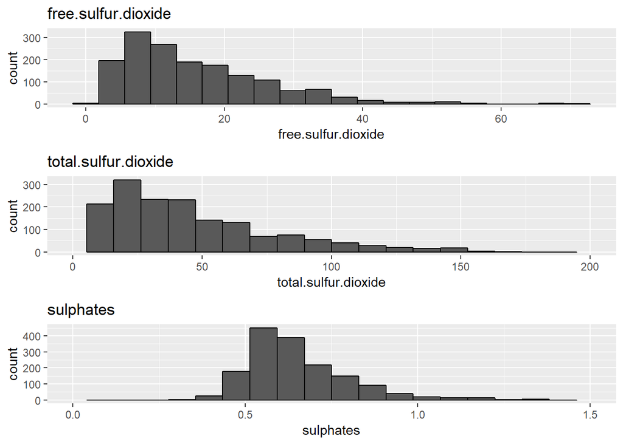

The frequencies for free and total sulfur dioxide similar may be due to total SO2 being the sum of free SO2 and bound forms of SO2. Although not naturally occuring, sulphates are added and can contritbute to SO2 levels.

```
##    Min. 1st Qu.  Median    Mean 3rd Qu.    Max.
##  0.9901  0.9956  0.9968  0.9967  0.9978  1.0037
```

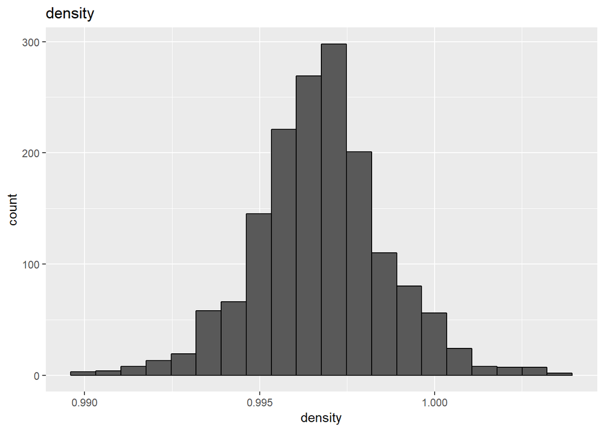

Density looks to be normally distributed with almost identical mean (0.9967) and median (0.9968).

```
##    Min. 1st Qu.  Median    Mean 3rd Qu.    Max.
##   2.740   3.210   3.310   3.311   3.400   4.010
```

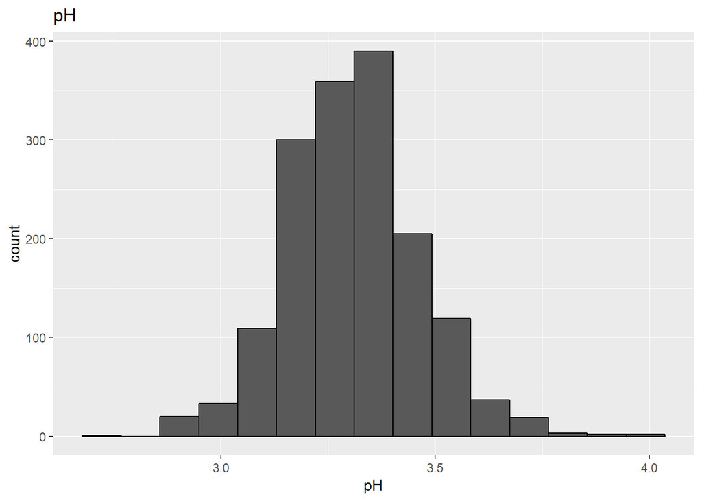

The histogram for pH shows a normal distribution centered at a median of 3.30. The mean pH is 3.31. Most wines tend to lie between 3-4 on the pH scale, making them acidic. This makes sense as controlling the acidity of wine is a very important during wine making.

```
##    Min. 1st Qu.  Median    Mean 3rd Qu.    Max.
##    8.40    9.50   10.20   10.42   11.10   14.90
```

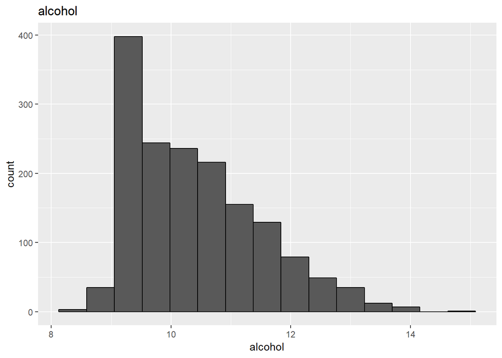

Like citric acid, alcohol content seems to have a different distrubiton. Adjusting the binwidth showed that alcohol leans right, and is almost like the second half of a normal distribution curve. The median and mean are almost equivalent (10.20, 10.42), but a good frequency of wines have alcohol content higher than the mean/median, ranging up to a max of 14.9 percent/volume.

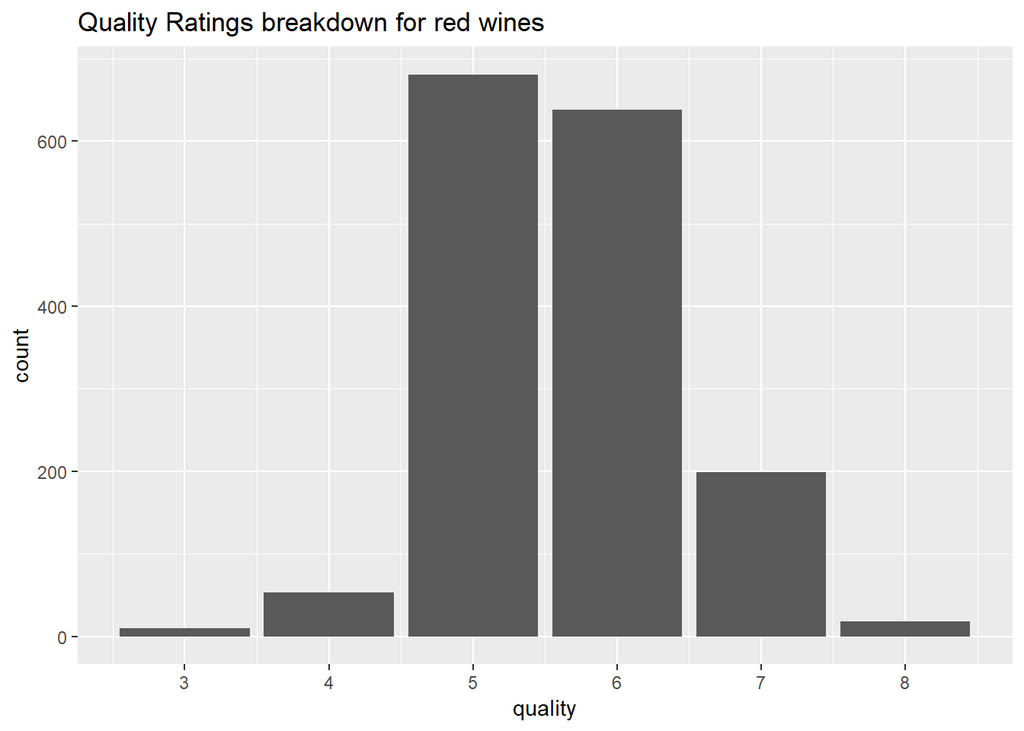

The quality rating, which in this case visuzlizes best with a bar chart shows that most of the ratings lie between 5-6 . The entire usable scale is 0-10, but our dataset only exhibits wine in the 3-8 qualilty range.

# Univariate Analysis

The red wine data contains 1599 observations(rows) and 12 variables (columns). Each variable represents a chemical attribute of red wine along with a ‘quality’ rating. Thus, the data is very favorable for comparing quality with specific attributes such as acidity or alcohol. Hisotgrams for each attribute that most are distributed normally with skew (mostly to the right). Some unusual distributions were exhibited with citric acid and alcohol content. With some adjustments to binwidth and x-axis to remove outliers, the distribution still failed to show they were normal.

# Bivariate Plots Section

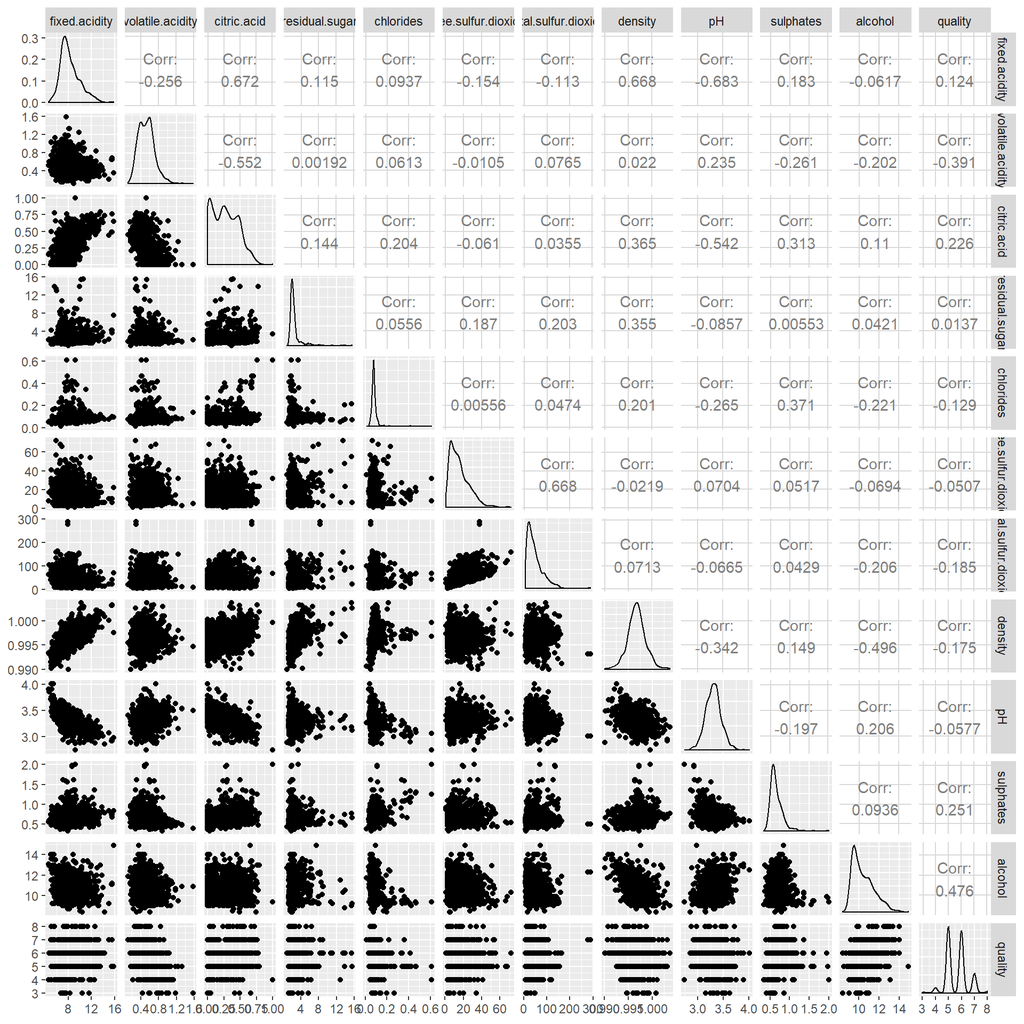

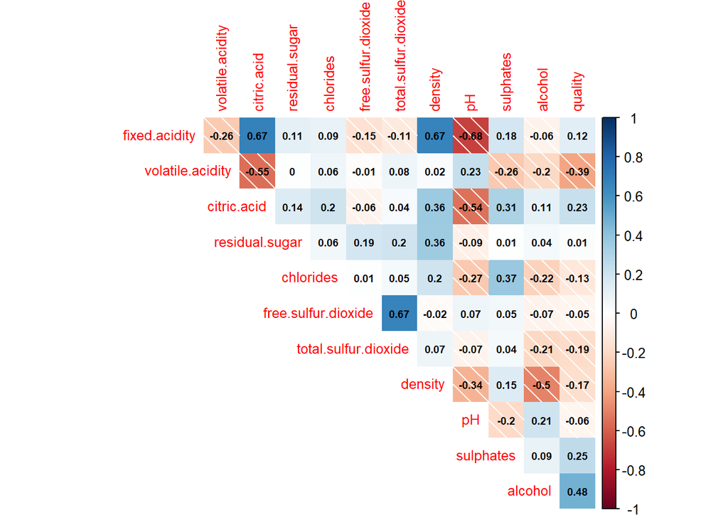

```
##                             [,1]
## fixed.acidity         0.12405165
## volatile.acidity     -0.39055778
## citric.acid           0.22637251
## residual.sugar        0.01373164
## chlorides            -0.12890656
## free.sulfur.dioxide  -0.05065606
## total.sulfur.dioxide -0.18510029
## density              -0.17491923
## pH                   -0.05773139
## sulphates             0.25139708
## alcohol               0.47616632
## quality               1.00000000
```

Using the GGally and corrplot library to create matrix plot, we can visualize a lot of details in a single plot to explore any points of interest. Since this data looks to find what attributes contribute to quality, we look for positive correlations when comparing to quality. For example, we may assume that alcohol content may contribute to higher quality ratings and find that, while not particularly high (corr = 0.476), it is the strongest factor in unlocking a good quality rating. Though there are some negative correlations associated with quality, volatile acid content has the largest impact on lowering quality rating.

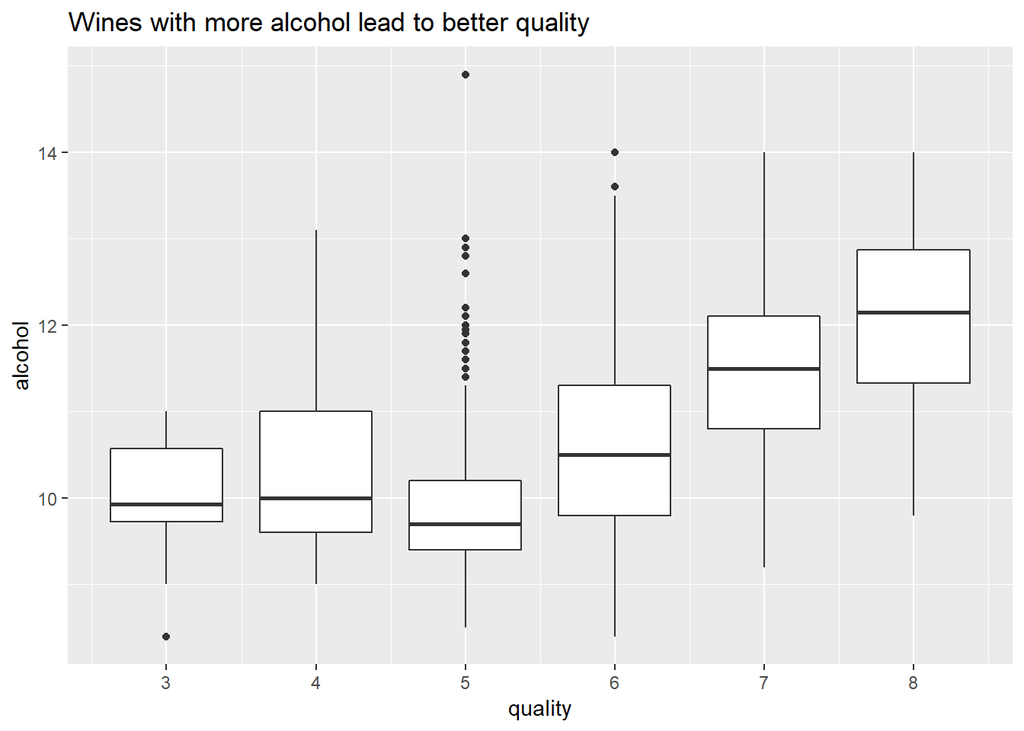

Even if there is overlap, we see that the median alcohol rises as quality rises with the exception at rating 5.

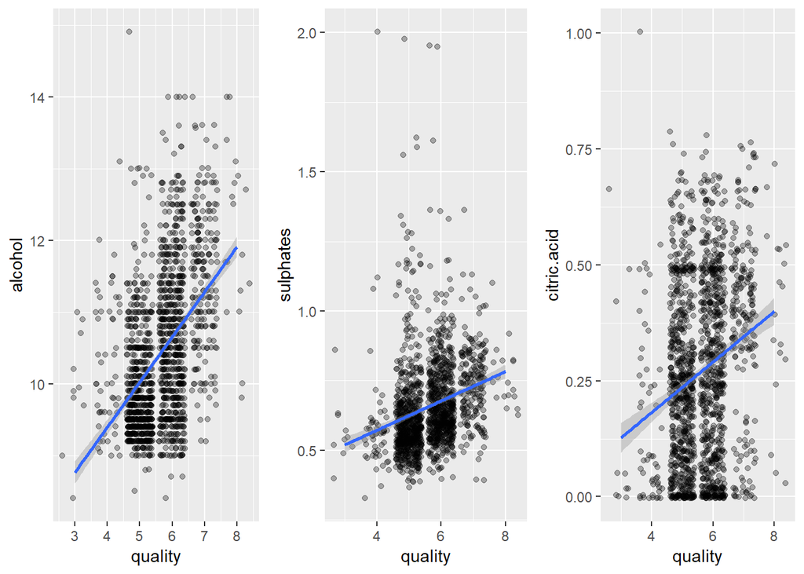

Comparing the three attributes with the highest correlations to quality rating, we see that alcohol content has a stronger effect on quality. The higer the alcohol content, the higher the quality rating given. This may make some sense in a social aspect as the effects of alcohol may lead to a more favorable mood. Citric acid is not naturally found in wine, and can be added in small amounts to give a freshness and additional flavor to the wine. This also seems to line up with a better quality rating as the citric acid adds freshness lead and potentially better tasting wine.

Sulphates are also an additive which are used to prevent microbial growth and oxidation. They may also, though minimally, contribute to both species of sulfur dioxide (SO2) which, at high enough concentrations, can change the aroma and flavor profile.

```
## factor(df$quality): 3
##    Min. 1st Qu.  Median    Mean 3rd Qu.    Max.
##   8.400   9.725   9.925   9.955  10.575  11.000
## --------------------------------------------------------
## factor(df$quality): 4
##    Min. 1st Qu.  Median    Mean 3rd Qu.    Max.
##    9.00    9.60   10.00   10.27   11.00   13.10
## --------------------------------------------------------
## factor(df$quality): 5
##    Min. 1st Qu.  Median    Mean 3rd Qu.    Max.
##     8.5     9.4     9.7     9.9    10.2    14.9
## --------------------------------------------------------
## factor(df$quality): 6
##    Min. 1st Qu.  Median    Mean 3rd Qu.    Max.
##    8.40    9.80   10.50   10.63   11.30   14.00
## --------------------------------------------------------
## factor(df$quality): 7
##    Min. 1st Qu.  Median    Mean 3rd Qu.    Max.
##    9.20   10.80   11.50   11.47   12.10   14.00
## --------------------------------------------------------
## factor(df$quality): 8
##    Min. 1st Qu.  Median    Mean 3rd Qu.    Max.
##    9.80   11.32   12.15   12.09   12.88   14.00
```

```
## factor(df$quality): 3
##    Min. 1st Qu.  Median    Mean 3rd Qu.    Max.
##  0.0000  0.0050  0.0350  0.1710  0.3275  0.6600
## --------------------------------------------------------
## factor(df$quality): 4
##    Min. 1st Qu.  Median    Mean 3rd Qu.    Max.
##  0.0000  0.0300  0.0900  0.1742  0.2700  1.0000
## --------------------------------------------------------
## factor(df$quality): 5
##    Min. 1st Qu.  Median    Mean 3rd Qu.    Max.
##  0.0000  0.0900  0.2300  0.2437  0.3600  0.7900
## --------------------------------------------------------
## factor(df$quality): 6
##    Min. 1st Qu.  Median    Mean 3rd Qu.    Max.
##  0.0000  0.0900  0.2600  0.2738  0.4300  0.7800
## --------------------------------------------------------
## factor(df$quality): 7
##    Min. 1st Qu.  Median    Mean 3rd Qu.    Max.
##  0.0000  0.3050  0.4000  0.3752  0.4900  0.7600
## --------------------------------------------------------
## factor(df$quality): 8
##    Min. 1st Qu.  Median    Mean 3rd Qu.    Max.
##  0.0300  0.3025  0.4200  0.3911  0.5300  0.7200
```

```
## factor(df$quality): 3
##    Min. 1st Qu.  Median    Mean 3rd Qu.    Max.
##  0.4000  0.5125  0.5450  0.5700  0.6150  0.8600
## --------------------------------------------------------
## factor(df$quality): 4
##    Min. 1st Qu.  Median    Mean 3rd Qu.    Max.
##  0.3300  0.4900  0.5600  0.5964  0.6000  2.0000
## --------------------------------------------------------
## factor(df$quality): 5
##    Min. 1st Qu.  Median    Mean 3rd Qu.    Max.
##   0.370   0.530   0.580   0.621   0.660   1.980
## --------------------------------------------------------
## factor(df$quality): 6
##    Min. 1st Qu.  Median    Mean 3rd Qu.    Max.
##  0.4000  0.5800  0.6400  0.6753  0.7500  1.9500
## --------------------------------------------------------
## factor(df$quality): 7
##    Min. 1st Qu.  Median    Mean 3rd Qu.    Max.
##  0.3900  0.6500  0.7400  0.7413  0.8300  1.3600
## --------------------------------------------------------
## factor(df$quality): 8
##    Min. 1st Qu.  Median    Mean 3rd Qu.    Max.
##  0.6300  0.6900  0.7400  0.7678  0.8200  1.1000
```

Interestingly, while examining the effects per quality rating, alcohol content at rating 5 actually had a lower mean than at rating 4. This may be due a number of factors including a higher frequency of wines rated at 5 comparted to 4. However, it’s a noteworthy finding considering I assumed that the mean alcohol concentration would continually increase with higher quality ratings.

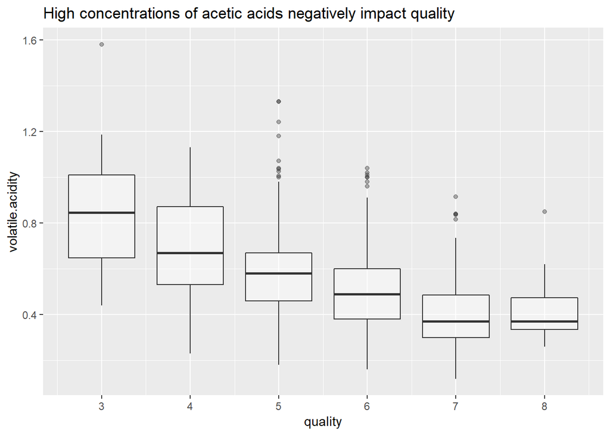

Not surprisingly, higher concentrations of volatile acids (acetic acid) has a negative impact on quality. This makes sense since high concentrations of acetic acid give off a “vinegar” taste and aroma.

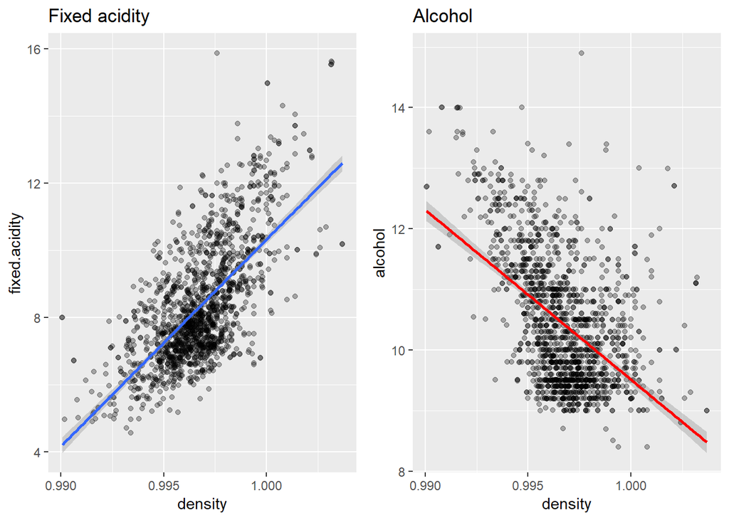

It’s interesting to see how how the acids contribute to density. Fixed acidity, which is essentially a measure of all naturally occruing acids contained in wine makes up a large proportion of the body. In contrast, the higher the alcohol content the less dense the wine. This challenges my own assumptions as I associate denser full bodied wines as less acidic. In this collection, at least, this is not the case.

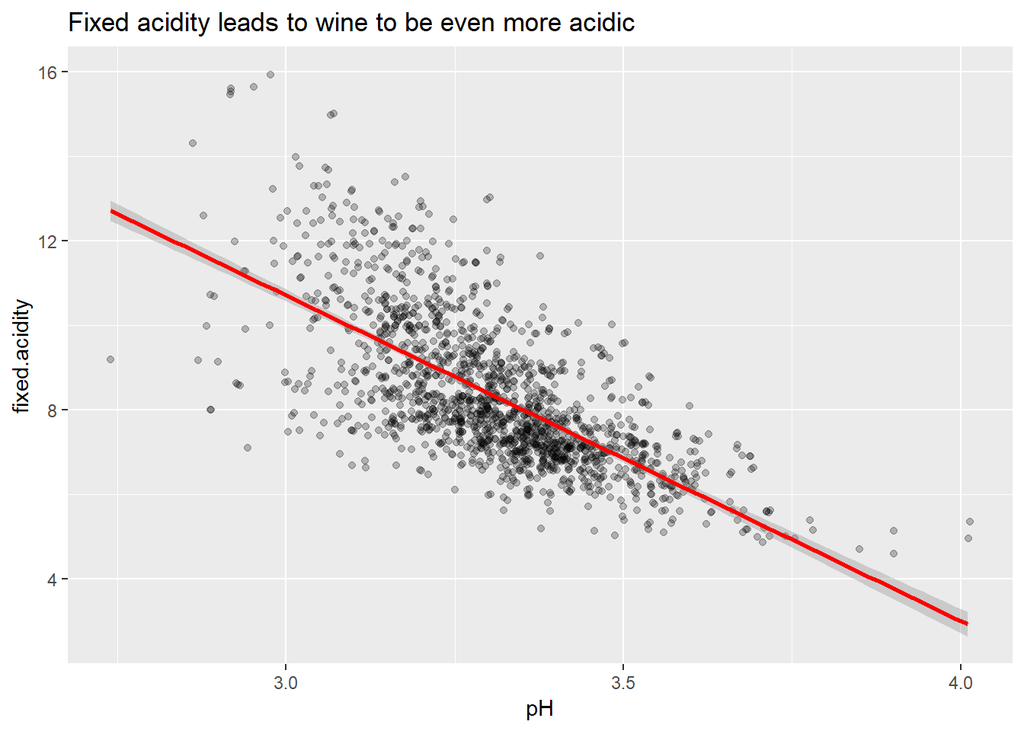

[output not shown]

[output cut: 342 more lines]

[output not shown]

Not surprisingly, though to a small range, high fixed acidity levels lead to an even lower pH. Again, this explains whey wines can be tart, as acidic liquids consumed tend to be sour or tart.

# Bivariate Analysis

When comparing quality, alcohol, citric acid, and sulphates emerged as the three attributes with the strongest positive correlation. I generated scatter plots (with some jitter to spread the quality points) and added a trendline to visualize the magnitude of an effect. In contrast, the attribute with the largest negative correlation was volatile acid content.

Another interesting relationship was comparing density with fixed acidity and alcohol, which gave strong, though opposite correlations. Here we found that higher acidity led to more denser wines. However, higher alcohol content denser wines would be due to presence of more alcohol and more acidic wines being less dense. Going futher, pH was more acidic the higher the fixed acid concentration. This finding also explains why pH has a moderate effect (-0.34) on higher density wines.

Overall the strongest positive correlations occurred between the following: -fixed acidity vs citric acid (R = 0.67) -fixed acidity vs density ( R= 0.67) -total SO2 vs free SO2 (R = 0.67) -pH vs fixed acidity (R = -0.68) -density vs alcohol (R = -0.50)

# Multivariate Plots Section

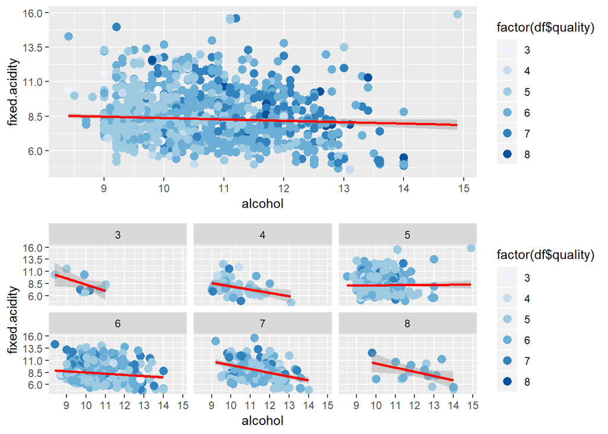

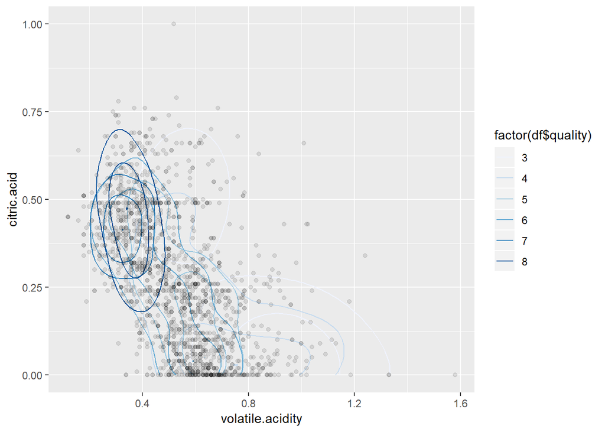

Since the other two acid attributes did effect quality of wine, I wanted to visualize citric acid vs volatile acid and wrap them in a cluster of specific quality. Here we can see that, due to the most of the darker colored clusters occuring on the left hand side of the plot, citric acid with minimal volatile acidity concentrations leads to better quality wines.

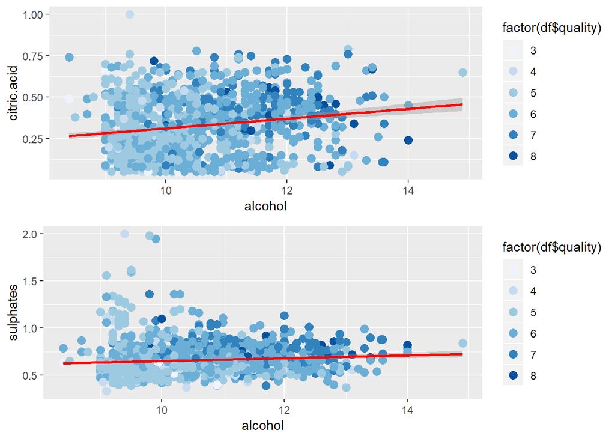

# Multivariate Analysis

Comparing fixed acidity and alcohol and their relationship with quality was interesting even though the fixed acidity correlation is relatively weak (R=0.12). However, acidity has an postive correlation on density, while alcohol has a strong negative impact on density. If we’re looking at the effects on quality, alcohol content is important to higher quality. Density, and by extension, the acidic components in a wine do not.

Further, the non-naturally occuring attributes introduced into wine, citric acid and sulphates, have a positive effect on good quality wines. This may be due to thier small effect to be associated with wines containing higher alcohol content.

# Final Plots and Summary

### Plot One

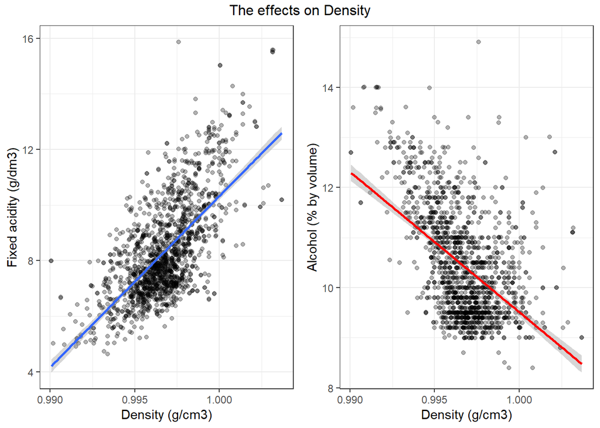

### Description One

This plot really shows how the relationship between acidity, alcohol, and density of the wine. Fixed acidity is increased due to the grapes and their skin, thus, giving a heavier profile. Increasing alcohol content made the wine less dense, and likely, of a lighter profile.

### Plot Two

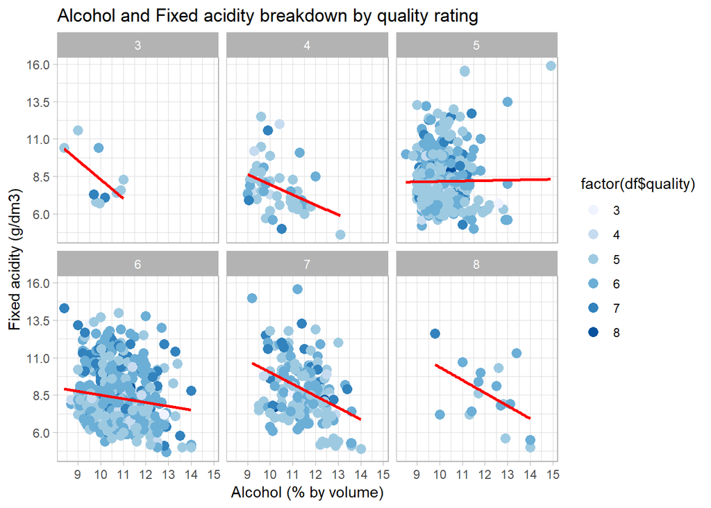

### Description Two

I feel that this plot really shows how much alcohol affects quality. You can see at quality 3 and 4 that most of the points are at the left side of the plots, meaning lowere alcohol content. Contrast that to the wines with ratings of 7-8 where the points are more prevalent to the center and right side of the x-axis, meaning higher alcohol. Similarly, we can see how acidity and wine have an almost inverse relationship with themselves, but also how fixed acidity essentially has not effect on quality.

### Plot Three

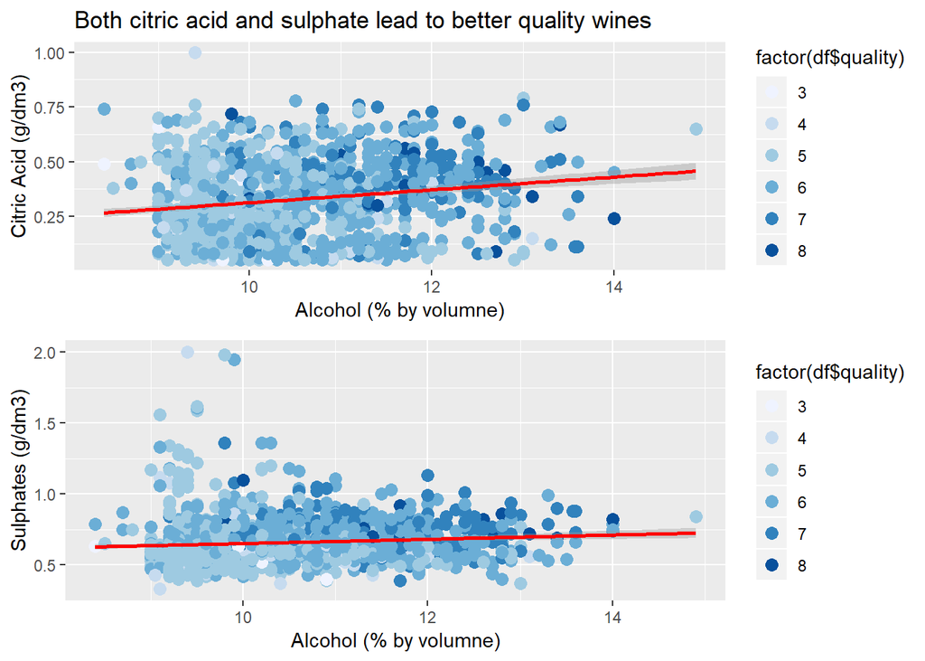

### Description Three

At this point we knew that alcohol was the most important factor in higher quality wine, but wanted to see if the additives have a positive effect on increasing alcohol content, thus, improving wine quality. It’s hard to tell if these additives improved quality by modifying the profile and aroma of wine, or if they also strengthened the alcohol content.

# Reflection

So upon completing the project, I realized I had a tough time getting started due to a lack of domain knowledge. The data set itself was really tidy and easy to work with, but without knowing what attributes do what, and what the data is trying to say, it’s hard to find a story to tell. After the univariate analysis, I took a lot of time reading about wine chemistry to understand how various attributes effect wine quality. It was interesting to see how additives (citric acid and sulphates) used to add freshness and protect from further microbial growth, actually led to better quality wine. However, seeing that they also are correlated positively with more alcohol content in a wine, we question whether the additives themselves and their ability to improve a wines taste and aroma are the cause of better wine. It was interesting project, and a reminder that, while learning how to work with powerful analytical tools such as R are important, having subject knowledge on the topic simply cannot be overlooked exploring a problem.

I think further analysis can be one a wine with a wider quality rating range, as when you really consider these wines, the majority of them are average and makes it difficult to really tease out what really makes a stand out wine. Further, exploring whether a specific blend of attributes can lead to a quality wine would be an interesting problem to tackle.

References:

https://www.homebrewit.com/a-detailed-explanation-of-acids-used-in-wine-making

https://winefolly.com/wine-basics-beginners-guide/

https://www.rstudio.com/resources/cheatsheets/

https://s3.amazonaws.com/udacity-hosted-downloads/ud651/wineQualityInfo.txt